# Collaboration and Competition

In this notebook, you will learn how to use the Unity ML-Agents environment for the third project of the [Deep Reinforcement Learning Nanodegree](https://www.udacity.com/course/deep-reinforcement-learning-nanodegree--nd893) program.

### 1. Start the Environment

We begin by importing the necessary packages. If the code cell below returns an error, please revisit the project instructions to double-check that you have installed [Unity ML-Agents](https://github.com/Unity-Technologies/ml-agents/blob/master/docs/Installation.md) and [NumPy](http://www.numpy.org/).

```python
from unityagents import UnityEnvironment
import numpy as np
from ddpg_agent import Agent, load_and_run
from collections import deque
import torch
```

```
cuda:0
```

Next, we will start the environment! *Before running the code cell below*, change the `file_name` parameter to match the location of the Unity environment that you downloaded.

- **Mac**: `"path/to/Tennis.app"`
- **Windows** (x86): `"path/to/Tennis_Windows_x86/Tennis.exe"`
- **Windows** (x86_64): `"path/to/Tennis_Windows_x86_64/Tennis.exe"`
- **Linux** (x86): `"path/to/Tennis_Linux/Tennis.x86"`
- **Linux** (x86_64): `"path/to/Tennis_Linux/Tennis.x86_64"`
- **Linux** (x86, headless): `"path/to/Tennis_Linux_NoVis/Tennis.x86"`
- **Linux** (x86_64, headless): `"path/to/Tennis_Linux_NoVis/Tennis.x86_64"`

For instance, if you are using a Mac, then you downloaded `Tennis.app`. If this file is in the same folder as the notebook, then the line below should appear as follows:

```
env = UnityEnvironment(file_name="Tennis.app")
```

```python
env = UnityEnvironment(file_name="Tennis_Windows_x86_64/Tennis.exe")
```

```
INFO:unityagents:
'Academy' started successfully!
Unity Academy name: Academy
        Number of Brains: 1
        Number of External Brains : 1
        Lesson number : 0
        Reset Parameters :

Unity brain name: TennisBrain
        Number of Visual Observations (per agent): 0
        Vector Observation space type: continuous
        Vector Observation space size (per agent): 8
        Number of stacked Vector Observation: 3
        Vector Action space type: continuous
        Vector Action space size (per agent): 2
        Vector Action descriptions: ,
```

Environments contain *brains* which are responsible for deciding the actions of their associated agents. Here we check for the first brain available, and set it as the default brain we will be controlling from Python.

```python
# get the default brain
brain_name = env.brain_names[0]
brain = env.brains[brain_name]
```

### 2. Examine the State and Action Spaces

In this environment, two agents control rackets to bounce a ball over a net. If an agent hits the ball over the net, it receives a reward of +0.1. If an agent lets a ball hit the ground or hits the ball out of bounds, it receives a reward of -0.01. Thus, the goal of each agent is to keep the ball in play.

The observation space consists of 8 variables corresponding to the position and velocity of the ball and racket. Two continuous actions are available, corresponding to movement toward (or away from) the net, and jumping.

Run the code cell below to print some information about the environment.

```python
# reset the environment
env_info = env.reset(train_mode=True)[brain_name]

# number of agents
num_agents = len(env_info.agents)
print('Number of agents:', num_agents)

# size of each action
action_size = brain.vector_action_space_size
print('Size of each action:', action_size)

# examine the state space
states = env_info.vector_observations
state_size = states.shape[1]
print('There are {} agents. Each observes a state with length: {}'.format(states.shape[0], state_size))
print('The state for the first agent looks like:', states[0])
```

```
Number of agents: 2
Size of each action: 2
There are 2 agents. Each observes a state with length: 24
The state for the first agent looks like: [ 0.          0.          0.          0.          0.          0.
  0.          0.          0.          0.          0.          0.
  0.          0.          0.          0.         -6.65278625 -1.5
 -0.          0.          6.83172083  6.         -0.          0.        ]
```

### 3. Define the Learning Process with Deep Deterministic Policy Gradient Method

The learning process using the Deep Deterministic Policy Gradient method is defined below (ddpg). The input parameters are described in the comments below. The outputs are list of the maximum scores for each episode and a list of the maimum scores averaged over the current and preceding 99 episodes (100-episode averages). The episodes before 100 just have averages over the preceding scores although there are less than 100.

```python
def ddpg(
    agent,
    n_episodes=2000,
    max_t=1500,
    print_every=100,
    gamma_initial = 0.9,
    gamma_final = 0.99,
    gamma_rate = 0.002,
    tau_initial = 0.02,
    tau_final = 0.001,
    tau_rate = 0.001,
    noise_factor = 1.0
):
    """
    Reinforcement learning with Deep Deterministic Policy Gradients
    n_episodes (int): Maximum number of training episodes
    max_t (int): Maximum number of timesteps per episode
    epsilon_initial (float): Initial value of epsilon for epsilon-greedy selection of an action
    epsilon_final (float): Final value of epsilon
    epsilon_rate (float): A rate (0.0 to 1.0) for decreasing epsilon for each episode. Higher is faster decay.
    gamma_initial (float): Initial gamma discount factor (0 to 1). Higher values favor long term over current rewards.
    gamma_final (float): Final gamma discount factor (0 to 1).
    gammma_rate (float): A rate (0 to 1) for increasing gamma.
    beta_initial (float): For prioritized replay. Corrects bias induced by weighted sampling of stored experiences.
        The beta parameters have no effect if the agent has prioritized experience replay activated.
    beta_rate (float): Rate (0 to 1) for increasing beta to 1 as per Schauel et al. https://arxiv.org/abs/1511.05952
    tau_initial (float): Initial value for tau, the weighting factor for soft updating the neural network.
        The tau parameters have no effect if the agent uses fixed Q targets instead of soft updating.
    tau_final (float): Final value of tau.
    tau_rate (float): Rate (0 to 1) for increasing tau each episode.

    Returned values:
        max_scores[]: The maximum scores for each episode.
        avg_max_scores[]: The maximum scores averaged over the maximum score for the current episode and the preceding
            99 episodes (100-episode averages).

    """

    gamma = gamma_initial
    gamma_scale = 1.0 - gamma_rate

    tau = tau_initial
    tau_scale = 1.0 - tau_rate

    noise_scale = 1.0

    success = False
    first05 = False
    both05 = False
    both1 = False

    max_scores_deque = deque(maxlen = print_every)
    #scores_deque = deque(maxlen=print_every)
    #scores = []
    max_scores = []
    avg_max_scores = []
    best_avg_max = 0.0
    best_agent_max = 0.0
    for i_episode in range(1, n_episodes+1):

        # Reset environment
        env_info = env.reset(train_mode=True)[brain_name]

        # Get next state
        state = env_info.vector_observations

        # state = env.reset()
        agent.reset()

        score = np.zeros(agent.num_agents)

        for t in range(max_t):

            # Get actions
            action = agent.act(state, noise_scale)
            #print(action)

            # Send actions to the environment
            env_info = env.step(action)[brain_name]

            # Get next state
            next_state = env_info.vector_observations

            # Get rewards
            reward = env_info.rewards

            # Check if episode is finished
            done = env_info.local_done

            # Make the agent proceed to the next timestep in the environment
            agent.step(state, action, reward, next_state, done, gamma, tau)

            # Add rewards to scores
            score += reward

            # Replace the current state with the next state for the next episode
            state = next_state

            # Exit if episode is finished
            if np.any(done):
                break

        #print('Total score (averaged over agents) this episode: {}'.format(np.mean(score)))
        agent_avg = np.mean(score)
        agent_max = np.max(score)
        agent_min = np.min(score)
        max_scores.append(agent_max)
        max_scores_deque.append(agent_max)
        avg_max = np.mean(max_scores_deque)
        avg_max_scores.append(avg_max)
        #scores_deque.append(agent_avg)
        #scores.append(agent_avg)
        avg_score = np.mean(max_scores_deque)

        print('Ep {}\tEp AvgMax: {:.4f}\tAg1: {:.4f}\tAg2: {:.4f}\tMax: {:.4f}\tg: {:.4f}\tns: {:.4f}\ttau: {:.4f}'.format(
            i_episode, avg_max, score[0], score[1], agent_max, gamma, noise_scale, tau))
        if not first05 and agent_max > 0.5:
            first05 = True
            torch.save(agent.actor_local.state_dict(), 'checkpoint_actor_first.pth')
            torch.save(agent.critic_local.state_dict(), 'checkpoint_critic_first.pth')
            print("Agent max score >0.5 after {:d} episodes.".format(i_episode))
        if not both05 and score[0] > 0.5 and score[1] > 0.5:
            both05 = True
            torch.save(agent.actor_local.state_dict(), 'checkpoint_actor_both05.pth')
            torch.save(agent.critic_local.state_dict(), 'checkpoint_critic_both05.pth')
            print("Both agents score >0.5 after {:d} episodes.".format(i_episode))
        if not both1 and score[0] > 1.0 and score[1] > 1.0:
            both1 = True
            best_agent_max = agent_max
            torch.save(agent.actor_local.state_dict(), 'checkpoint_actor_both1.pth')
            torch.save(agent.critic_local.state_dict(), 'checkpoint_critic_both1.pth')
            print("Both agents score >1 after {:d} episodes.".format(i_episode))
        if i_episode >=100 and not success and avg_max > 0.5:
            success = True
            best_avg_max = avg_max
            torch.save(agent.actor_local.state_dict(), 'checkpoint_actor.pth')
            torch.save(agent.critic_local.state_dict(), 'checkpoint_critic.pth')
            print("100-episode-average max score >0.5 after {:d} episodes.".format(i_episode))
        if success and avg_max > best_avg_max:
            best_avg_max = avg_max
            torch.save(agent.actor_local.state_dict(), 'checkpoint_actor_best_avg_max.pth')
            torch.save(agent.critic_local.state_dict(), 'checkpoint_critic_best_avg_max.pth')
            print("New best 100-episode-average at Episode {:d}.".format(i_episode))
        if both1 and agent_max > best_agent_max:
            best_agent_max = agent_max
            torch.save(agent.actor_local.state_dict(), 'checkpoint_actor_best_agent_max.pth')
            torch.save(agent.critic_local.state_dict(), 'checkpoint_critic_best_agent_max.pth')
            print("New best agent maximum score at Episode {:d}.".format(i_episode))

        # Increase gamma discount factor. Limit to gamma_final.
        gamma = gamma_final - gamma_scale * (gamma_final - gamma)

        tau = tau_final - tau_scale * (tau_final - tau)

        noise_scale *= noise_factor

    torch.save(agent.actor_local.state_dict(), 'checkpoint_actor_final.pth')
    torch.save(agent.critic_local.state_dict(), 'checkpoint_critic_final.pth')
    return max_scores, avg_max_scores
```

## 4. Declare the Learning Agent

Agent has the following parameters:

```
state_size: Number of parameters defining the environment state
action_size: Number of pameters defining the actions
num_agents: Number of learning agents
random_seed: Random seed number
batch_size: Batch size for neural network training
lr_actor: Learning rate for the actor neural network
lr_critic: Learning rate for the critic neural network
noise_theta (float): theta for Ornstein-Uhlenbeck noise process
noise_sigma (float): sigma for Ornstein-Uhlenbeck noise process
actor_fc1 (int): Number of hidden units in the first fully connected layer of the actor network
actor_fc2: Units in second layer
actor_fc3: Units in third fully connected layer. This parameter does nothing for the "RELU" network
critic_fc1: Number of hidden units in the first fully connected layer of the critic network
critic_fc2: Units in second layer
critic_fc3: Units in third layer. This parameter does nothing for the "RELU" network
update_every: The number of time steps between each updating of the neural networks
num_updates: The number of times to update the networks at every update_every interval
buffer_size: Buffer size for experience replay. Default 2e6.
network (string): The name of the neural networks that are used for learning.
    There are only 2 choices, one with only 2 fully connected layers and RELU activations and one
    with 3 fully connected layers with SELU activations.
    Their names are "RELU" and "SELU," respectively. Default is "RELU."
```

```python
agent = Agent(
    state_size = state_size,
    action_size = action_size,
    num_agents = num_agents,
    random_seed = 0,
    batch_size = 1024,
    lr_actor = 0.001,
    lr_critic = 0.001,
    noise_theta = 0.1,
    noise_sigma = 0.05,
    actor_fc1 = 128,
    actor_fc2 = 128,
    critic_fc1 = 128,
    critic_fc2 = 128,
    update_every = 20,
    num_updates = 15,
    buffer_size = int(2e6)
)
```

## 5. Train the Agent

Perform the training and collect the scores. The following are printed for every episode:

```
Ep: The episode number
Ep AvgMax: The agent-maximum score averaged over the current episode and and previous 99 episodes.
Ag1: The score for the first agent for the current episode
Ag2: The score for the second agent.
Max: The maximum of the 2 scores
g: The gamma discount factor for the current episode.
ns: The noise scaling factor for the current episode.
tau: The weight factor used for soft updating for the current episode.

Messages will appear to notify the user when various achievements occur:
    1. First time achieving an agent maximum score of 0.5
    2. First time both agents score >0.5
    3. First time both agents score >1
    3. Each time a new best agent-maximum score is achieved (after achievement 3)
    4. First time the 100-episode-average maximum score >0.5 (after at least 100 episodes)
    5. Each time a new best 100-episode-average maximum score is achieved (after achievement 4)

    A checkpoint is saved at each of these notifications. The checkpoints are overwritten for 3 and 5.
```

```python
max_scores, avg_max_scores = ddpg(
    agent,
    n_episodes = 2000,
    max_t = 10000,
    gamma_initial = 0.95,
    gamma_final = 0.99,
    gamma_rate = 0.01,
    tau_initial = 0.01,
    tau_final = 0.001,
    tau_rate = 0.001,
    noise_factor = 0.9999
)
```

```
Ep 1	Ep AvgMax: 0.0000	Ag1: 0.0000	Ag2: -0.0100	Max: 0.0000	g: 0.9500	ns: 1.0000	tau: 0.0100
Ep 2	Ep AvgMax: 0.0000	Ag1: 0.0000	Ag2: -0.0100	Max: 0.0000	g: 0.9504	ns: 0.9999	tau: 0.0100
Ep 3	Ep AvgMax: 0.0000	Ag1: 0.0000	Ag2: -0.0100	Max: 0.0000	g: 0.9508	ns: 0.9998	tau: 0.0100
Ep 4	Ep AvgMax: 0.0000	Ag1: 0.0000	Ag2: -0.0100	Max: 0.0000	g: 0.9512	ns: 0.9997	tau: 0.0100
Ep 5	Ep AvgMax: 0.0000	Ag1: 0.0000	Ag2: -0.0100	Max: 0.0000	g: 0.9516	ns: 0.9996	tau: 0.0100
Ep 6	Ep AvgMax: 0.0000	Ag1: -0.0100	Ag2: 0.0000	Max: 0.0000	g: 0.9520	ns: 0.9995	tau: 0.0100
Ep 7	Ep AvgMax: 0.0000	Ag1: 0.0000	Ag2: -0.0100	Max: 0.0000	g: 0.9523	ns: 0.9994	tau: 0.0099
Ep 8	Ep AvgMax: 0.0000	Ag1: -0.0100	Ag2: 0.0000	Max: 0.0000	g: 0.9527	ns: 0.9993	tau: 0.0099
Ep 9	Ep AvgMax: 0.0000	Ag1: 0.0000	Ag2: -0.0100	Max: 0.0000	g: 0.9531	ns: 0.9992	tau: 0.0099
Ep 10	Ep AvgMax: 0.0000	Ag1: 0.0000	Ag2: -0.0100	Max: 0.0000	g: 0.9535	ns: 0.9991	tau: 0.0099
Ep 11	Ep AvgMax: 0.0000	Ag1: 0.0000	Ag2: -0.0100	Max: 0.0000	g: 0.9538	ns: 0.9990	tau: 0.0099
Ep 12	Ep AvgMax: 0.0000	Ag1: 0.0000	Ag2: -0.0100	Max: 0.0000	g: 0.9542	ns: 0.9989	tau: 0.0099
Ep 13	Ep AvgMax: 0.0000	Ag1: 0.0000	Ag2: -0.0100	Max: 0.0000	g: 0.9545	ns: 0.9988	tau: 0.0099
Ep 14	Ep AvgMax: 0.0000	Ag1: 0.0000	Ag2: -0.0100	Max: 0.0000	g: 0.9549	ns: 0.9987	tau: 0.0099
Ep 15	Ep AvgMax: 0.0000	Ag1: 0.0000	Ag2: -0.0100	Max: 0.0000	g: 0.9553	ns: 0.9986	tau: 0.0099
Ep 16	Ep AvgMax: 0.0000	Ag1: 0.0000	Ag2: -0.0100	Max: 0.0000	g: 0.9556	ns: 0.9985	tau: 0.0099
Ep 17	Ep AvgMax: 0.0000	Ag1: -0.0100	Ag2: 0.0000	Max: 0.0000	g: 0.9559	ns: 0.9984	tau: 0.0099
Ep 18	Ep AvgMax: 0.0000	Ag1: -0.0100	Ag2: 0.0000	Max: 0.0000	g: 0.9563	ns: 0.9983	tau: 0.0098
Ep 19	Ep AvgMax: 0.0000	Ag1: -0.0100	Ag2: 0.0000	Max: 0.0000	g: 0.9566	ns: 0.9982	tau: 0.0098
Ep 20	Ep AvgMax: 0.0045	Ag1: 0.0900	Ag2: 0.0000	Max: 0.0900	g: 0.9570	ns: 0.9981	tau: 0.0098
Ep 21	Ep AvgMax: 0.0043	Ag1: 0.0000	Ag2: -0.0100	Max: 0.0000	g: 0.9573	ns: 0.9980	tau: 0.0098
Ep 22	Ep AvgMax: 0.0041	Ag1: 0.0000	Ag2: -0.0100	Max: 0.0000	g: 0.9576	ns: 0.9979	tau: 0.0098
Ep 23	Ep AvgMax: 0.0039	Ag1: 0.0000	Ag2: -0.0100	Max: 0.0000	g: 0.9579	ns: 0.9978	tau: 0.0098
Ep 24	Ep AvgMax: 0.0038	Ag1: 0.0000	Ag2: -0.0100	Max: 0.0000	g: 0.9583	ns: 0.9977	tau: 0.0098
Ep 25	Ep AvgMax: 0.0036	Ag1: -0.0100	Ag2: 0.0000	Max: 0.0000	g: 0.9586	ns: 0.9976	tau: 0.0098
Ep 26	Ep AvgMax: 0.0035	Ag1: 0.0000	Ag2: -0.0100	Max: 0.0000	g: 0.9589	ns: 0.9975	tau: 0.0098
Ep 27	Ep AvgMax: 0.0033	Ag1: 0.0000	Ag2: -0.0100	Max: 0.0000	g: 0.9592	ns: 0.9974	tau: 0.0098
Ep 28	Ep AvgMax: 0.0032	Ag1: 0.0000	Ag2: -0.0100	Max: 0.0000	g: 0.9595	ns: 0.9973	tau: 0.0098
Ep 29	Ep AvgMax: 0.0062	Ag1: 0.0000	Ag2: 0.0900	Max: 0.0900	g: 0.9598	ns: 0.9972	tau: 0.0098
Ep 30	Ep AvgMax: 0.0060	Ag1: 0.0000	Ag2: -0.0100	Max: 0.0000	g: 0.9601	ns: 0.9971	tau: 0.0097
Ep 31	Ep AvgMax: 0.0058	Ag1: -0.0100	Ag2: 0.0000	Max: 0.0000	g: 0.9604	ns: 0.9970	tau: 0.0097
Ep 32	Ep AvgMax: 0.0056	Ag1: 0.0000	Ag2: -0.0100	Max: 0.0000	g: 0.9607	ns: 0.9969	tau: 0.0097
Ep 33	Ep AvgMax: 0.0055	Ag1: 0.0000	Ag2: -0.0100	Max: 0.0000	g: 0.9610	ns: 0.9968	tau: 0.0097
Ep 34	Ep AvgMax: 0.0053	Ag1: 0.0000	Ag2: -0.0100	Max: 0.0000	g: 0.9613	ns: 0.9967	tau: 0.0097
Ep 35	Ep AvgMax: 0.0051	Ag1: -0.0100	Ag2: 0.0000	Max: 0.0000	g: 0.9616	ns: 0.9966	tau: 0.0097
Ep 36	Ep AvgMax: 0.0050	Ag1: 0.0000	Ag2: -0.0100	Max: 0.0000	g: 0.9619	ns: 0.9965	tau: 0.0097
Ep 37	Ep AvgMax: 0.0049	Ag1: 0.0000	Ag2: -0.0100	Max: 0.0000	g: 0.9621	ns: 0.9964	tau: 0.0097
Ep 38	Ep AvgMax: 0.0047	Ag1: -0.0100	Ag2: 0.0000	Max: 0.0000	g: 0.9624	ns: 0.9963	tau: 0.0097
Ep 39	Ep AvgMax: 0.0046	Ag1: 0.0000	Ag2: -0.0100	Max: 0.0000	g: 0.9627	ns: 0.9962	tau: 0.0097
Ep 40	Ep AvgMax: 0.0045	Ag1: 0.0000	Ag2: -0.0100	Max: 0.0000	g: 0.9630	ns: 0.9961	tau: 0.0097
```

[output cut: 2118 more lines]

```
Ep 1986	Ep AvgMax: 2.3289	Ag1: 2.6000	Ag2: 2.6000	Max: 2.6000	g: 0.9900	ns: 0.8200	tau: 0.0022
Ep 1987	Ep AvgMax: 2.3299	Ag1: 2.7000	Ag2: 2.6000	Max: 2.7000	g: 0.9900	ns: 0.8199	tau: 0.0022
Ep 1988	Ep AvgMax: 2.3289	Ag1: 2.6000	Ag2: 2.6000	Max: 2.6000	g: 0.9900	ns: 0.8198	tau: 0.0022
Ep 1989	Ep AvgMax: 2.3289	Ag1: 2.6000	Ag2: 2.7000	Max: 2.7000	g: 0.9900	ns: 0.8197	tau: 0.0022
Ep 1990	Ep AvgMax: 2.3108	Ag1: 0.2900	Ag2: 0.2000	Max: 0.2900	g: 0.9900	ns: 0.8196	tau: 0.0022
Ep 1991	Ep AvgMax: 2.2878	Ag1: 0.3000	Ag2: 0.1900	Max: 0.3000	g: 0.9900	ns: 0.8195	tau: 0.0022
Ep 1992	Ep AvgMax: 2.2618	Ag1: -0.0100	Ag2: 0.1000	Max: 0.1000	g: 0.9900	ns: 0.8195	tau: 0.0022
Ep 1993	Ep AvgMax: 2.2368	Ag1: -0.0100	Ag2: 0.1000	Max: 0.1000	g: 0.9900	ns: 0.8194	tau: 0.0022
Ep 1994	Ep AvgMax: 2.2358	Ag1: 2.6000	Ag2: 2.6000	Max: 2.6000	g: 0.9900	ns: 0.8193	tau: 0.0022
Ep 1995	Ep AvgMax: 2.2298	Ag1: 2.1000	Ag2: 1.9900	Max: 2.1000	g: 0.9900	ns: 0.8192	tau: 0.0022
Ep 1996	Ep AvgMax: 2.2078	Ag1: 0.2900	Ag2: 0.4000	Max: 0.4000	g: 0.9900	ns: 0.8191	tau: 0.0022
Ep 1997	Ep AvgMax: 2.2068	Ag1: 2.6000	Ag2: 2.6000	Max: 2.6000	g: 0.9900	ns: 0.8191	tau: 0.0022
Ep 1998	Ep AvgMax: 2.2058	Ag1: 2.5900	Ag2: 2.6000	Max: 2.6000	g: 0.9900	ns: 0.8190	tau: 0.0022
Ep 1999	Ep AvgMax: 2.2058	Ag1: 2.6000	Ag2: 2.6000	Max: 2.6000	g: 0.9900	ns: 0.8189	tau: 0.0022
Ep 2000	Ep AvgMax: 2.2088	Ag1: 2.6000	Ag2: 2.7000	Max: 2.7000	g: 0.9900	ns: 0.8188	tau: 0.0022
```

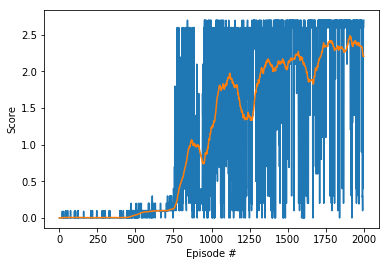

```python
import matplotlib.pyplot as plt

#avg_mask = np.ones(100) / 100
#score_avg= np.convolve(scores, avg_mask, 'valid')

fig = plt.figure()
ax = fig.add_subplot(111)
plt.plot(np.arange(1, len(max_scores)+1), max_scores)
plt.plot(np.arange(1, len(max_scores)+1), avg_max_scores, label='avg')
plt.ylabel('Score')
plt.xlabel('Episode #')
plt.show()
```

## 6. Run the Trained Agent

```python
# Define the agent again. This is not necessary if the entire notebook was run from the beginning.
# However, I had to run this section again and did not want to repeat the learningin in Section 5.

agent = Agent(
    state_size = state_size,
    action_size = action_size,
    num_agents = num_agents,
    random_seed = 19,
    actor_fc1 = 128,
    actor_fc2 = 128,
    critic_fc1 = 128,
    critic_fc2 = 128,
)
```

```python
load_and_run(agent, env, 'checkpoint_actor_best_avg_max.pth', 'checkpoint_critic_best_avg_max.pth', 100)
```

```
Ep 1	Score: 2.60
Ep 2	Score: 2.65
Ep 3	Score: 2.65
Ep 4	Score: 2.60
Ep 5	Score: 2.65
Ep 6	Score: 0.20
Ep 7	Score: 2.55
Ep 8	Score: 2.60
Ep 9	Score: 2.60
Ep 10	Score: 0.25
Ep 11	Score: 2.60
Ep 12	Score: 2.65
Ep 13	Score: 2.65
Ep 14	Score: 2.60
Ep 15	Score: 2.65
Ep 16	Score: 0.10
Ep 17	Score: 2.60
Ep 18	Score: 2.55
Ep 19	Score: 2.65
Ep 20	Score: 2.65
Ep 21	Score: 2.60
Ep 22	Score: 2.65
Ep 23	Score: 2.65
Ep 24	Score: 2.60
Ep 25	Score: 2.65
Ep 26	Score: 2.65
Ep 27	Score: 2.65
Ep 28	Score: 2.60
Ep 29	Score: 2.65
Ep 30	Score: 2.65
Ep 31	Score: 2.60
Ep 32	Score: 2.65
Ep 33	Score: 2.65
Ep 34	Score: 1.25
Ep 35	Score: 0.10
Ep 36	Score: 0.15
Ep 37	Score: 2.60
Ep 38	Score: 0.30
Ep 39	Score: 2.60
Ep 40	Score: 2.65
```

[output cut: 46 more lines]

```
Ep 87	Score: 2.65
Ep 88	Score: 0.40
Ep 89	Score: 2.60
Ep 90	Score: 2.60
Ep 91	Score: 2.65
Ep 92	Score: 2.65
Ep 93	Score: 2.60
Ep 94	Score: 2.65
Ep 95	Score: 2.65
Ep 96	Score: 2.60
Ep 97	Score: 2.65
Ep 98	Score: 0.25
Ep 99	Score: 2.60
Ep 100	Score: 0.25
Avg over 100 episodes: 2.24
```

```python
load_and_run(agent, env, 'checkpoint_actor_best_agent_max.pth', 'checkpoint_critic_best_agent_max.pth', 100)
```

```
Ep 1	Score: 2.60
Ep 2	Score: 2.65
Ep 3	Score: 2.65
Ep 4	Score: 2.65
Ep 5	Score: 2.65
Ep 6	Score: 2.60
Ep 7	Score: 2.65
Ep 8	Score: 2.65
Ep 9	Score: 2.65
Ep 10	Score: -0.00
Ep 11	Score: 2.60
Ep 12	Score: 2.65
Ep 13	Score: 2.65
Ep 14	Score: 2.65
Ep 15	Score: 2.65
Ep 16	Score: 2.60
Ep 17	Score: 2.65
Ep 18	Score: 2.65
Ep 19	Score: 2.65
Ep 20	Score: 0.05
Ep 21	Score: 2.60
Ep 22	Score: 2.65
Ep 23	Score: 2.65
Ep 24	Score: 2.60
Ep 25	Score: 2.65
Ep 26	Score: 2.65
Ep 27	Score: 2.65
Ep 28	Score: 2.65
Ep 29	Score: 2.65
Ep 30	Score: 0.10
Ep 31	Score: 2.60
Ep 32	Score: 2.65
Ep 33	Score: -0.00
Ep 34	Score: 2.60
Ep 35	Score: 2.65
Ep 36	Score: 2.65
Ep 37	Score: 2.65
Ep 38	Score: -0.00
Ep 39	Score: 2.60
Ep 40	Score: 2.65
```

[output cut: 46 more lines]

```
Ep 87	Score: 2.65
Ep 88	Score: 0.05
Ep 89	Score: 2.60
Ep 90	Score: 2.65
Ep 91	Score: 2.65
Ep 92	Score: 2.65
Ep 93	Score: 2.65
Ep 94	Score: 2.65
Ep 95	Score: 2.65
Ep 96	Score: 2.60
Ep 97	Score: 2.65
Ep 98	Score: 2.65
Ep 99	Score: 2.65
Ep 100	Score: 2.65
Avg over 100 episodes: 2.35
```

When finished, you can close the environment.

```python
env.close()
```